# Education System in California

### Shouvik Chakraborty Xavier Zientarski

Given that California is among the most diverse and the most populous state in America [1], we have decided to create a tutorial that analyzes the education system in California. This tutorial will include data tidying, exploratory analysis, visualization, data training, and data testing. We will be using pandas, folium, seaborn, and scikit-learn among other python libraries to accomplish these tasks. Our goal is to demonstrate how someone’s race/ethnicity, gender, school grade, and location in the State of California could affect educational achievements. We will mostly focus on the probability that a student will drop out of high school, and the probability that a student is qualified to start higher education after high school graduation. </br>

This tutorial will try to answer three main questions:

#### 1) What is the prospect of having a student that will dropout given their race, gender, and grade?

```
For this question, one needs to consider six important variables:
County (location), gender, race/ethnicity, grade, number of dropout students, and number of graduating students.
```

#### 2) Which are the counties with the lowest education performance?

```
Given the data from the previous question, find which are the counties that are not performing as well as others.
```

#### 3) How feasible is it for a student to meet the UC/CSU (college) entrance requirements?

```
UC/CSU (UC requirement) are the California State University entrance requirements. With this question, we are trying to analyze if a high school graduate is capable to attend a university directly with no supplementary courses.
This question will be analyzed using the following variables:
County (location), gender, number of graduating students, number of dropout students, and number of graduating students who qualify for the UC requirement.
```

### About the Data

We will collect the data to answer the questions stated above. We will only be using data from schools where a student can graduate with a GED; i.e., high schools or institutions where 12th grade material taught. We will be using several datasets that can be found on the California Department of Education website [website](https://www.cde.ca.gov/). There is plenty of data on this website, but one still needs to organize the data, since it is not sufficiently organized to use it to answer the three questions stated above. We will be using data from the school year 2008-2009 to the year 2014-2015 for data analysis and data training, this includes seven school years. We will use the school year 2015-2016 to test our prediction from the training.

### Import Libraries

```
We will to import all the libraries that will be needed for this tutorial. <br/>We also have to set pandas' column display to a value higher than 100. This will help us see all the column values that we will have available. We will be using the following libraries:
```

- We will be using pandas to create and organize the dataframes.
- Folium will help with geographical visualization. This will be used to create a choropleth graph for question 2.
- Request and json will allow us to get GEOjson files from the web.
- Seaborn will help us to visualize the data into different kinds of plot charts.
- BeatifulSoup will help to scrape data for question 2.
- All the scikit-learn (sklearn) libraries will be used for data training and data testing.
- Scipy will also be used for data training.
- matplot will be used for visualization in the data testing section.

```python
!pip install folium
import pandas as pd
import folium
import requests
import json
import seaborn as sns
from bs4 import BeautifulSoup

from sklearn import svm
from sklearn import cross_validation
from sklearn.model_selection import cross_val_score
from sklearn.model_selection import KFold
from sklearn.ensemble import RandomForestRegressor
from scipy import stats
import matplotlib.pyplot as plt

pd.options.display.max_columns = 200
```

## Data Tidying

```
Create a function called 'year_df()'.
This function will get three datasets from the website:
  a) Dropout by Ethnicity
  b) Dropout by Race
  c) Graduate by Ethnicity/Race
These data can be acquired from the website as text files. We have downloaded these files and uploaded them to a GitHub repository so we can access the raw data.
The reason we are using these datasets is because these have information to answer three of our questions.
Dataset a), that is named location in the function, has similar data as dataset b). The difference between these two is that Dataset a) has the school codes (CDS_CODE), the county where the school is located, and the name of the school. Dataset b) has CDS_CODE information and dropout data, but no data on location.

We will use dataset b) to get information about dropout and enrolled students grouped by grade, gender and race. This dataset also includes the sum of the previous data for grades 9 to 12.

Data set c) gives you the number of students who graduate every year by race, and gender. Additionally, there is the UC requirement qualification data discussed above.

The function will organize the data so it can later be used for testing and data analysis. Finally, these dataset will be merged into a bigger data frame that will give you the data for one school year.

The argument 'year' is a two-digit integer for the year. In order to get data for school year 2011-2012, one should set '12' as the argument.
It is also important to remark that one should organized the names of the datasets a), b), and c) in a uniform way such that it is easy to access it and one could simply distinguish it by the year. Check the third to fifth lines of the function to see the how this works.
```

### Variables

#### Gender

```
Gender will be simply organized as (M) for male and (F) for female. Therefore, one can get data for female students who drop out in the 10th grade, or male students who graduate but do not pass the UC requirements.
```

#### Race/Ethnicity

```
Currently there area 8 ethnicity denominations in the state of California. We will only use two denominations: (min) for minority, and (maj) for majority or European American.
The reason to use this denomination is because 59% percent of population is European American in California. And the rest comprises of Hispanics, Native Americans, African Americans, Asian American, Filipino, Pacific Islander or Hawaiian, and Undeclared.
This binary denomination will come in handy in counties where there is less diversity. For that reason, it would hard to train and analyze data for all races and ethnicities who go to a certain school where there are only one or two them. Minority gives us a higher number to work with.
```

```python
def year_df(year):
    #DataFrames
    location = pd.read_csv("https://rawgit.com/shouvik95/Education-System-in-California/master/ethnicity"+ str(year) +".txt",delimiter="\t")
    graduates = pd.read_csv("https://rawgit.com/shouvik95/Education-System-in-California/master/filesgradsRG"+ str(year) +".txt",delimiter="\t")
    dropouts = pd.read_csv("https://rawgit.com/shouvik95/Education-System-in-California/master/filesdropouts"+ str(year) +".txt",delimiter="\t")

    #Get Location data from grad by ethnicity
    location = location.groupby(['CDS_CODE', 'COUNTY', 'DISTRICT', 'SCHOOL'])['TOTAL'].sum().reset_index().drop(['TOTAL'], axis=1)

    #Dropout
    dropouts = dropouts[dropouts.ETOT != 0]

    for index,row in  dropouts.iterrows():
        col = row.GENDER
        dropouts.at[index, col + "_ETOT"] = row.ETOT
        dropouts.at[index, col + "_DTOT"] = row.DTOT

        dropouts.at[index, col + "_E9"] = row.E9
        dropouts.at[index, col + "_E10"] = row.E10
        dropouts.at[index, col + "_E11"] = row.E11
        dropouts.at[index, col + "_E12"] = row.E12

        dropouts.at[index, col + "_D9"] = row.D9
        dropouts.at[index, col + "_D10"] = row.D10
        dropouts.at[index, col + "_D11"] = row.D11
        dropouts.at[index, col + "_D12"] = row.D12

        if row.ETHNIC == 9:
            col = 'maj'
        else:
            col = 'min'

        dropouts.at[index, col + "_ETOT"] = row.ETOT
        dropouts.at[index, col + "_DTOT"] = row.DTOT

        dropouts.at[index, col + "_E9"] = row.E9
        dropouts.at[index, col + "_E10"] = row.E10
        dropouts.at[index, col + "_E11"] = row.E11
        dropouts.at[index, col + "_E12"] = row.E12

        dropouts.at[index, col + "_D9"] = row.D9
        dropouts.at[index, col + "_D10"] = row.D10
        dropouts.at[index, col + "_D11"] = row.D11
        dropouts.at[index, col + "_D12"] = row.D12


    dropouts = dropouts.fillna(0)
    dropouts = dropouts.groupby(['CDS_CODE'])['ETOT', 'DTOT','M_ETOT','M_DTOT','M_E9','M_E10','M_E11','M_E12', "min_ETOT","min_DTOT","min_E9","min_E10","min_E11","min_E12","min_D9","min_D10","min_D11","min_D12", "F_ETOT","F_DTOT","F_E9","F_E10","F_E11","F_E12","F_D9","F_D10","F_D11","F_D12","maj_ETOT","maj_DTOT","maj_E9","maj_E10","maj_E11","maj_E12",'maj_D9','maj_D10','maj_D11','maj_D12'].sum().reset_index()

    #Graduates
    for index,row in  graduates.iterrows():
        col = row.GENDER
        graduates.at[index, col + "_GRADS"] = row.GRADS
        graduates.at[index, col + "_UC_GRADS"] = row.UC_GRADS

        if row.ETHNIC == 9:
            col = 'maj'
        else:
            col = 'min'

        graduates.at[index, col + "_GRADS"] = row.GRADS
        graduates.at[index, col + "_UC_GRADS"] = row.UC_GRADS

    graduates = graduates.fillna(0)
    graduates = graduates.groupby(['CDS_CODE'])['GRADS', 'UC_GRADS', 'M_GRADS','M_UC_GRADS','min_GRADS','min_UC_GRADS','F_GRADS','F_UC_GRADS','maj_GRADS','maj_UC_GRADS'].sum().reset_index()

    df = pd.merge(location, dropouts, on='CDS_CODE')


    return pd.merge(df, graduates, on='CDS_CODE')
```

#### Create a data frame for 2009

```python
df2009 = year_df('09')
df2009.head(5)
```

|  | CDS_CODE | COUNTY | DISTRICT | SCHOOL | ETOT | DTOT | M_ETOT | M_DTOT | M_E9 | M_E10 | M_E11 | M_E12 | min_ETOT | min_DTOT | min_E9 | min_E10 | min_E11 | min_E12 | min_D9 | min_D10 | min_D11 | min_D12 | F_ETOT | F_DTOT | F_E9 | F_E10 | F_E11 | F_E12 | F_D9 | … |
| --- | --- | --- | --- | --- | --- | --- | --- | --- | --- | --- | --- | --- | --- | --- | --- | --- | --- | --- | --- | --- | --- | --- | --- | --- | --- | --- | --- | --- | --- | --- |
| 0 | 1100170109835 | Alameda | Alameda County Office of Education | FAME Public Charter | 297 | 19 | 108.0 | 7.0 | 29.0 | 23.0 | 29.0 | 27.0 | 224.0 | 19.0 | 67.0 | 48.0 | 57.0 | 52.0 | 4.0 | 4.0 | 4.0 | 7.0 | 189.0 | 12.0 | 63.0 | 48.0 | 42.0 | 36.0 | 3.0 | … |
| 1 | 1100170130401 | Alameda | Alameda County Office of Education | Alameda County Juvenile Hall/Court | 323 | 465 | 295.0 | 377.0 | 15.0 | 57.0 | 70.0 | 153.0 | 317.0 | 465.0 | 16.0 | 65.0 | 75.0 | 161.0 | 46.0 | 61.0 | 84.0 | 274.0 | 28.0 | 88.0 | 1.0 | 8.0 | 8.0 | 11.0 | 12.0 | … |
| 2 | 1100170130419 | Alameda | Alameda County Office of Education | Alameda County Community | 168 | 95 | 122.0 | 72.0 | 26.0 | 33.0 | 46.0 | 17.0 | 168.0 | 95.0 | 37.0 | 45.0 | 59.0 | 27.0 | 22.0 | 29.0 | 24.0 | 20.0 | 46.0 | 23.0 | 11.0 | 12.0 | 13.0 | 10.0 | 5.0 | … |
| 3 | 1100170130427 | Alameda | Alameda County Office of Education | Alameda County Opportunity | 79 | 43 | 4.0 | 2.0 | 3.0 | 1.0 | 0.0 | 0.0 | 79.0 | 43.0 | 26.0 | 21.0 | 13.0 | 19.0 | 14.0 | 14.0 | 8.0 | 7.0 | 75.0 | 41.0 | 23.0 | 20.0 | 13.0 | 19.0 | 13.0 | … |
| 4 | 1316170131763 | Alameda | California School for the Deaf-Fremont (State ... | California School for the Deaf-Fremont | 208 | 7 | 107.0 | 5.0 | 28.0 | 27.0 | 27.0 | 21.0 | 207.0 | 7.0 | 53.0 | 43.0 | 51.0 | 47.0 | 2.0 | 1.0 | 2.0 | 2.0 | 101.0 | 2.0 | 25.0 | 17.0 | 24.0 | 26.0 | 0.0 | … |

## Explaining the Data

This section will help you understand the data that we currently have.

```
CDS_CODE = The specific code given to a school
County = A country in California
District = An education district
School = School's name

ETOT = (Enrolled Total) The total number of students enrolled at a school.
DTOT = (Dropped Total) The total number of students who dropped at a school.
    *A dropout students does not count as an enrolled student. Therefore, these are independent values.

M_ETOT = (Male Enrolled Total)
M_DTOT = (Male Dropped Total)
M_E9 = (Male Enrolled 9th grade)
M_E10 = (Male Enrolled 10th grade)
M_E11 = (Male Enrolled 11th grade)
M_E12 = (Male Enrolled 12th grade)

M_D9 = (Male Dropped 9th grade)
M_D10 = (Male Dropped 10th grade)
M_D11 = (Male Dropped 11th grade)
M_D12 = (Male Dropped 12th grade)

F_ETOT = (Female Enrolled Total)
F_DTOT = (Female Dropped Total)
F_E9 = (Female Enrolled 9th grade)
F_E10 = (Female Enrolled 10th grade)
F_E11 = (Female Enrolled 11th grade)
F_E12 = (Female Enrolled 12th grade)

F_D9 = (Female Dropped 9th grade)
F_D10 = (Female Dropped 10th grade)
F_D11 = (Female Dropped 11th grade)
F_D12 = (Female Dropped 12th grade)

minETOT = (minority Enrolled Total)
minDTOT = (minority Dropped Total)
min_9 = (minority enrolled 10th grade)
min_10 = (minority enrolled 10th grade)
min_11 = (minority enrolled 11th grade)
min_12 = (minority enrolled 12th grade)

majETOT = (majority Enrolled Total)
majDTOT = (majority Dropped Total)
maj_9 = (majority enrolled 10th grade)
maj_10 = (majority enrolled 10th grade)
maj_11 = (majority enrolled 11th grade)
maj_12 = (majority enrolled 12th grade)


GRADS = Graduated students
UC_GRADS = Students who are qualified to attend a public university in California

F_GRADS = Female students who graduate
F_UC_GRADS = Female students capable to start Secondary education after graduation
M_GRADS = Male students who graduate
M_UC_UGRADS = Male students capable to start Secondary education after graduation

maj_GRADS = majority students who graduate
maj_UC_GRADS = majority students capable to start Secondary education after graduation
min_GRADS = minority students who graduate
min_UC_GRADS = minority students capable to start Secondary education after graduation
```

Load the data for the other years.

```python
df2010 = year_df(10)
df2011 = year_df(11)
df2012 = year_df(12)
```

```python
df2013 = year_df(13)
df2014 = year_df(14)
df2015 = year_df(15)
df2016 = year_df(16)
```

## Exploratory Data Analysis

In this section we will organize our data and see how to implement what we have so far to answer our main questions. In addition, we will use visualization tools to display the data in a manner that will help to comprehend the results better.

### 1) What is the prospect of having a student that will dropout given their background?

Our main concern here is to know how gender, race, school grade, and location (county where school is located) affect a students probability of dropping out of high school.

We will need to get the following variables from the dataset created above:

- Year: year pertaining information about a graduation year.
- Dropout percentage: The percentage that a student will drop out of high school.
  - To get this data we will need to follow this equation:  
    $Percentage$ $of$ $Dropping$ $out$ $ = \frac{Dropouts}{Dropouts+Graduates} * 100 $  
    Dropout students will be considered as students that should have graduated. Since, there are dropouts from all grades every year, they will be counted as a groups with the ones that are graduating.
- Dropout percentage for female students.
- Dropout percentage for male students.
- Dropout percentage for minorities: this includes all races except European Americans.
- Dropout percentage for majority: this only includes European Americans.
- Dropout percentage for 9th graders.
- Dropout percentage for 10th graders.
- Dropout percentage for 11th graders.
- Dropout percentage for 12th graders.

The following data will be used in question 3, but it will be collected now:

- UC graduates percentage: This is the percentage of students who are academically qualified to attend university.
  - We will get this number by using the following equation:  
    $Percentage$ $of$ $UC$ $graduates$ $ = \frac{UC Graduates}{Dropouts+Graduates} * 100 $  
    Remember that the number of dropouts and graduates is then number of students who should have graduated at a certain year. The number of UC students is equal or less than the number of graduating students.
- Female UC graduates percentage.
- Male UC graduates percentage.

The following function will help us to get these variables for one year only.

```python
def get_dropout_percentage(data, year):
  question1 = data.groupby('COUNTY')[list(data.columns.values)[4:]].sum().reset_index()

  question1['year'] = year

  question1['Drop_percentage'] = question1.apply(lambda row: (float(row.DTOT) /(row.DTOT + row.GRADS)) * 100 if row.DTOT + row.GRADS > 0 else 0, axis = 1)

  question1['Drop_percentage_M'] = question1.apply(lambda row: (float(row.M_DTOT) /(row.M_DTOT + row.M_GRADS)) * 100 if row.M_DTOT + row.M_GRADS > 0 else 0, axis = 1)
  question1['Drop_percentage_F'] = question1.apply(lambda row: (float(row.F_DTOT) /(row.F_DTOT + row.F_GRADS)) * 100 if row.F_DTOT + row.F_GRADS > 0 else 0, axis = 1)

  question1['Drop_percentage_min'] = question1.apply(lambda row: (float(row.min_DTOT) /(row.min_DTOT + row.min_GRADS)) * 100 if row.min_DTOT + row.min_GRADS > 0 else 0, axis = 1)
  question1['Drop_percentage_maj'] = question1.apply(lambda row: (float(row.maj_DTOT) /(row.maj_DTOT + row.maj_GRADS)) * 100 if row.maj_DTOT + row.maj_GRADS > 0 else 0, axis = 1)

  question1['Drop_percentage_9'] = question1.apply(lambda row: (float(row.min_D9 + row.maj_D9) /(row.min_E9 + row.maj_E9 + row.min_D9 + row.maj_D9)) * 100 if row.min_E9 + row.maj_E9 + row.min_D9 + row.maj_D9 > 0 else 0, axis = 1)
  question1['Drop_percentage_10'] = question1.apply(lambda row: (float(row.min_D10 + row.maj_D10) /(row.min_E10 + row.maj_E10 + row.min_D10 + row.maj_D10)) * 100 if row.min_E10 + row.maj_E10 + row.min_D10 + row.maj_D10 > 0 else 0, axis = 1)
  question1['Drop_percentage_11'] = question1.apply(lambda row: (float(row.min_D11 + row.maj_D11) /(row.min_E11 + row.maj_E11 + row.min_D11 + row.maj_D11)) * 100 if row.min_E11 + row.maj_E11 + row.min_D11 + row.maj_D11 > 0 else 0, axis = 1)
  question1['Drop_percentage_12'] = question1.apply(lambda row: (float(row.min_D12 + row.maj_D12) /(row.min_E12 + row.maj_E12 + row.min_D12 + row.maj_D12)) * 100 if row.min_E12 + row.maj_E12 + row.min_D12 + row.maj_D12 > 0 else 0, axis = 1)

  question1['UC_grads'] = question1.apply(lambda row: (float(row.UC_GRADS) /(row.DTOT + row.GRADS)) * 100,axis = 1)
  question1['F_UC_grads'] = question1.apply(lambda row: (float(row.F_UC_GRADS) /(row.F_DTOT + row.F_GRADS)) * 100 if row.F_DTOT + row.F_GRADS > 0 else 0,axis = 1)
  question1['M_UC_grads'] = question1.apply(lambda row: (float(row.M_UC_GRADS) /(row.M_DTOT + row.M_GRADS)) * 100 if row.M_DTOT + row.M_GRADS > 0 else 0,axis = 1)

  return question1.drop(list(question1.columns.values)[1:49], axis = 1)
```

Apply this function to all the dataframes.

```python
question1_2009 =  get_dropout_percentage(df2009, 2009)
question1_2010 =  get_dropout_percentage(df2010, 2010)
question1_2011 =  get_dropout_percentage(df2011, 2011)
question1_2012 =  get_dropout_percentage(df2012, 2012)
question1_2013 =  get_dropout_percentage(df2013, 2013)
question1_2014 =  get_dropout_percentage(df2014, 2014)
question1_2015 =  get_dropout_percentage(df2015, 2015)
question1_2016 =  get_dropout_percentage(df2016, 2016)

question1_2012.head(5)
```

|  | COUNTY | year | Drop_percentage | Drop_percentage_M | Drop_percentage_F | Drop_percentage_min | Drop_percentage_maj | Drop_percentage_9 | Drop_percentage_10 | Drop_percentage_11 | Drop_percentage_12 | UC_grads | F_UC_grads | M_UC_grads |
| --- | --- | --- | --- | --- | --- | --- | --- | --- | --- | --- | --- | --- | --- | --- |
| 0 | Alameda | 2012 | 15.223159 | 17.791411 | 12.557078 | 15.385082 | 9.388646 | 1.559939 | 2.316219 | 2.917834 | 7.845414 | 44.761512 | 49.375150 | 40.317166 |
| 1 | Amador | 2012 | 9.392265 | 9.677419 | 9.090909 | 9.275362 | 11.764706 | 1.479290 | 0.536193 | 2.144772 | 5.080214 | 22.928177 | 24.431818 | 21.505376 |
| 2 | Butte | 2012 | 12.435644 | 14.063714 | 10.743134 | 12.283528 | 21.428571 | 0.584063 | 1.495399 | 2.813203 | 6.748239 | 23.722772 | 27.059774 | 20.512821 |
| 3 | Calaveras | 2012 | 6.842105 | 7.920792 | 5.617978 | 6.739526 | 9.523810 | 0.000000 | 0.370370 | 2.072539 | 4.595588 | 21.578947 | 24.719101 | 18.811881 |
| 4 | Colusa | 2012 | 13.953488 | 18.079096 | 9.580838 | 13.994169 | 0.000000 | 0.613497 | 1.869159 | 3.125000 | 7.733333 | 19.476744 | 28.742515 | 10.734463 |

Combine all the dataframes to create a bigger dataframe for all these years.

```python
#Create a complete df
question1 = pd.concat([question1_2009, question1_2010, question1_2011, question1_2012, question1_2013, question1_2014, question1_2015])
```

The following code will help us to organize the data for Race and Gender and Grade so it could be displayed better using Seaborn plots.

```python
#Race
question1raceA = question1.copy(deep=True)
question1raceB = question1.copy(deep=True)
question1raceA['race']  = 'minority'
question1raceA['race_dropout'] = question1raceA['Drop_percentage_min']

question1raceB['race']  = 'majority'
question1raceB['race_dropout'] = question1raceB['Drop_percentage_maj']

#Gender
question1genderA = question1.copy(deep=True)
question1genderB = question1.copy(deep=True)
question1genderA['gender']  = 'female'
question1genderA['gender_dropout'] = question1genderA['Drop_percentage_F']

question1genderB['gender']  = 'male'
question1genderB['gender_dropout'] = question1genderB['Drop_percentage_M']

#Grade
question1grade9 = question1.copy(deep=True)
question1grade10 = question1.copy(deep=True)
question1grade11 = question1.copy(deep=True)
question1grade12 = question1.copy(deep=True)

question1grade9['grade']  = '9'
question1grade9['grade_dropout'] = question1raceA['Drop_percentage_9']

question1grade10['grade']  = '10'
question1grade10['grade_dropout'] = question1raceA['Drop_percentage_10']

question1grade11['grade']  = '11'
question1grade11['grade_dropout'] = question1raceA['Drop_percentage_11']

question1grade12['grade']  = '12'
question1grade12['grade_dropout'] = question1raceA['Drop_percentage_12']

race_drop_q1 = pd.concat([question1raceA, question1raceB])
gender_drop_q1 = pd.concat([question1genderA, question1genderB])
grade_drop_q1 = pd.concat([question1grade9, question1grade10, question1grade11, question1grade12])
gender_drop_q1.head(3)
```

|  | COUNTY | year | Drop_percentage | Drop_percentage_M | Drop_percentage_F | Drop_percentage_min | Drop_percentage_maj | Drop_percentage_9 | Drop_percentage_10 | Drop_percentage_11 | Drop_percentage_12 | UC_grads | F_UC_grads | M_UC_grads | gender | gender_dropout |
| --- | --- | --- | --- | --- | --- | --- | --- | --- | --- | --- | --- | --- | --- | --- | --- | --- |
| 0 | Alameda | 2009 | 25.955449 | 29.281116 | 22.510004 | 25.965124 | 23.750000 | 4.960621 | 5.252434 | 5.340174 | 10.992400 | 34.450753 | 38.939529 | 30.118026 | female | 22.510004 |
| 1 | Alpine | 2009 | 0.000000 | 0.000000 | 0.000000 | 0.000000 | 0.000000 | 0.000000 | 0.000000 | 0.000000 | 0.000000 | 0.000000 | 0.000000 | 0.000000 | female | 0.000000 |
| 2 | Amador | 2009 | 11.671088 | 11.170213 | 12.169312 | 10.833333 | 29.411765 | 0.840336 | 1.357466 | 1.555556 | 6.511628 | 23.607427 | 29.629630 | 17.553191 | female | 12.169312 |

Now all the data are ready for visualization.

### Visualization for Question 1

One can use a boxplot to get a sense of how the dropping out percentage has changed for the entire state.

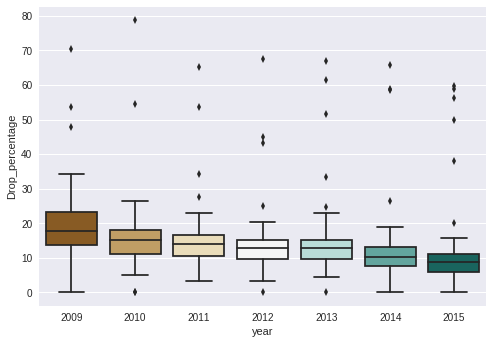

```python
 sns.boxplot(x="year", y="Drop_percentage", palette = 'BrBG', data=question1)
```

As the graph displays, we can see that the dropping out percentage has been decreasing, this is good news!  
There many outliers along the way. We will identify these low-performance counties in question 2.  
Another thing to point out is that the data is more spread-out in the first years. It appears that education is slowly being equalized all over California.

#### Gender, how does it affect the probability of dropping out?

If we look at a violin plot, it is clear that male students have a higher chance of dropping out.

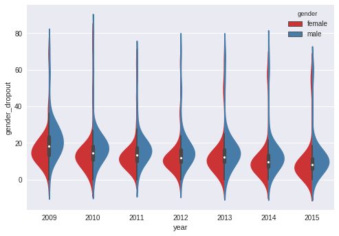

```python
sns.violinplot(x='year', y='gender_dropout', palette = 'Set1', hue="gender",  data=gender_drop_q1, split=True)
```

The violinplot shows that there are many outliers. These outliers represent counties that are not performing very well compared to others. One can always use a swarmplot to see the exactly where these outliers are located.

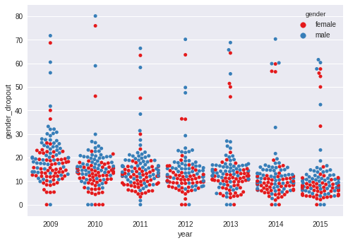

```python
sns.swarmplot(x="year", y="gender_dropout", palette = 'Set1', hue= "gender", data=gender_drop_q1)
```

The outliers are mostly male students. It is important to point out that, as the years pass, counties are starting to get the number of dropout students more condensed. This also applies to male and female students. Additionally, the number of counties with zero dropouts has stayed constant for the last four years.

#### Race, how does it affect the probability of dropping out?

Just like the previous section. We are going to use a violin plot.

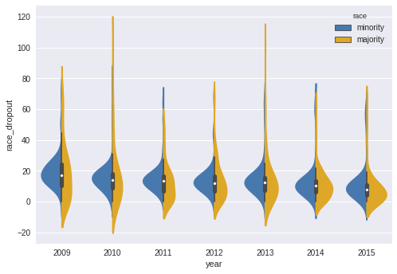

```python
color_set = (sns.xkcd_palette(["windows blue", "amber"]))
sns.violinplot(x='year', y='race_dropout', palette = color_set, hue="race",  data=race_drop_q1, split=True)
```

The graph suggests that, on average, the majority has a lower percentage average while the minority percentage average is a bit higher. Although, the majority percentages is more spread-out. Let's look at a swarmplot to see the data from a different perspective.

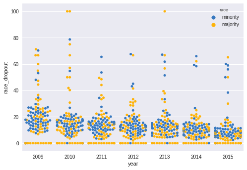

```python
sns.swarmplot(x="year", y="race_dropout",palette = color_set, hue= "race", data=race_drop_q1)
```

#### How does your grade affect your chance of dropping out?

For this section we will be using a swam plot with four variables for the grade.

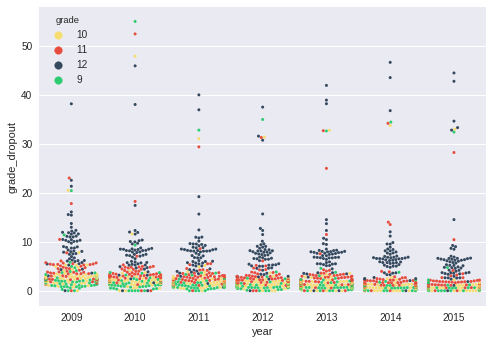

```python
# import matplotlib.pyplot as plt
# fig, ax = plt.subplots()
# fig.set_size_inches(13.7, 11.27)

colors =sns.color_palette( ["#f7dc6f","#e74c3c", "#34495e", "#2ecc71"])
sns.swarmplot(x="year", y="grade_dropout", hue="grade", palette = colors, size = 3,data=grade_drop_q1)
```

As the graph suggest, the percentage of dropping out in 12th grade is higher that other grades on average.

### 2) Which are the counties with the lowest education performance?

We will be using a map to see the counties that are not performing as well as other.

The following visualization will display the mean of the percentage of dropping out for the years 2009 to 2015 in a map. The map will allow us to see which county is not performing as well as others. We will need to use folium to display this map. We will also need to do data scraping to get the coodinates for the counties center coordinates for the makers. We will be using the GEOjson coordinates from found in this github repository [here](https://github.com/codeforamerica/click_that_hood/blob/master/public/data/california-counties.geojson). You can also find this GEOjason file [here](https://rawgit.com/shouvik95/Education-System-in-California/master/california-counties.geojson) as a raw file.

### Data Scraping

We will need to scrape data to get center geographic coordinates for the counties found in California. There are 58 counties in California. For this, we will need to scrape the data from a table on [Wikipedia](https://en.wikipedia.org/wiki/User:Michael_J/County_table)[2]. For this, we will need BeautifulSoup.

```python
WIKI_URL = "https://en.wikipedia.org/wiki/User:Michael_J/County_table"

req = requests.get(WIKI_URL)
soup = BeautifulSoup(req.content, 'html5lib')
table_classes = {"class": ["sortable", "plainrowheaders"]}
wikitables = soup.findAll("table", table_classes)

main_table = soup.find("table")
lst = pd.read_html(str(main_table), flavor='html5lib')
county_coordinates = lst[0]
```

Modify the latitude and longitude. Convert these to float so it can be read.

```python
county_coordinates.columns = county_coordinates.iloc[0]
county_coordinates.drop(county_coordinates.index[0], inplace=True)

county_coordinates = county_coordinates[county_coordinates.State == 'CA']
county_coordinates = county_coordinates.reset_index(drop=True)


county_coordinates['Latitude'] = county_coordinates.apply(lambda row: float(row.Latitude[:-1]), axis = 1)
county_coordinates['Longitude'] = county_coordinates.apply(lambda row: float( '-' + row.Longitude[1:-1]), axis = 1)

county_coordinates.head(3)
```

|  | Sort [1] | State | FIPS | County [2] | County Seat(s) [3] | Population (2010) | Land Area km² | Land Area mi² | Water Area km² | Water Area mi² | Total Area km² | Total Area mi² | Latitude | Longitude |
| --- | --- | --- | --- | --- | --- | --- | --- | --- | --- | --- | --- | --- | --- | --- |
| 0 | 187 | CA | 06001 | Alameda | Oakland | 1510271 | 1914.046 | 739.017 | 213.185 | 82.311 | 2127.231 | 821.328 | 37.648081 | -121.913304 |
| 1 | 188 | CA | 06003 | Alpine | Markleeville | 1175 | 1912.272 | 738.332 | 12.557 | 4.848 | 1924.829 | 743.180 | 38.617610 | -119.798999 |
| 2 | 189 | CA | 06005 | Amador | Jackson | 38091 | 1539.963 | 594.583 | 29.457 | 11.373 | 1569.420 | 605.956 | 38.443550 | -120.653856 |

We also need to get the dropout percentage mean for all the years we are analyzing.

```python
question2 = question1.groupby(['COUNTY'])['Drop_percentage'].mean().reset_index()
question2.head(3)
```

|  | COUNTY | Drop_percentage |
| --- | --- | --- |
| 0 | Alameda | 15.565925 |
| 1 | Alpine | 16.666667 |
| 2 | Amador | 10.888624 |

### Visualization

Finally, we display a choropleth graph the percentages per county. The graph will include markers with the name of the county and the dropout percentage mean for the seven years we worked on in question 1.

```python
r = requests.get('https://rawgit.com/shouvik95/Education-System-in-California/master/california-counties.geojson')

m = folium.Map(location=[37, -120], zoom_start=6)

m.choropleth(r.json(),
          data = question2,
          name = 'Dropout percentage',
          columns = ['COUNTY', 'Drop_percentage'],
          key_on = 'feature.properties.name',
          fill_color = 'YlGnBu',#'YlOrRd',
          line_opacity = 0.9,
          #highlight=True,
          legend_name = '2012')


for index, row in county_coordinates.iterrows():
  folium.RegularPolygonMarker(number_of_sides=6,
    location=[row.Latitude, row.Longitude],radius=6,  color='black', fill_color= 'black',
    popup=row['County [2]'] + ":  "+ str(float((question2.loc[question2['COUNTY'] == row['County [2]']]).Drop_percentage))[0:5]  ).add_to(m)

m
```

[interactive chart not shown]

```python
Inyo = question1.loc[question1.COUNTY == 'Inyo']
Trinity = question1.loc[question1.COUNTY == 'Trinity']
Nevada = question1.loc[question1.COUNTY == 'Nevada']
Sierra = question1.loc[question1.COUNTY == 'Sierra']
counties = pd.concat([Inyo, Trinity, Nevada, Sierra])
```

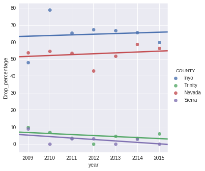

```python
sns.lmplot(x="year", y="Drop_percentage", hue='COUNTY', data=counties, ci=None)
```

As it's shown here, the two worst counties, Inyo and Nevada, appear to be increasing the number of dropout students slowly. While the two lowest, Trinity and Sierra, are decreasing slowly.

### 3) How feasible is it for a student to meet the UC/CSU (college) entrance requirements?

For this question we simply organize the data from question1 to create datasets for UC qualified graduates.

```python
#Gender
question3genderA = question1.copy(deep=True)
question3genderB = question1.copy(deep=True)
question3genderA['gender']  = 'female'
question3genderA['gender_UC'] = question3genderA['F_UC_grads']

question3genderB['gender']  = 'male'
question3genderB['gender_UC'] = question3genderB['M_UC_grads']

gender_UC_q3 = pd.concat([question3genderA, question3genderB])
gender_UC_q3.head(3)
```

|  | COUNTY | year | Drop_percentage | Drop_percentage_M | Drop_percentage_F | Drop_percentage_min | Drop_percentage_maj | Drop_percentage_9 | Drop_percentage_10 | Drop_percentage_11 | Drop_percentage_12 | UC_grads | F_UC_grads | M_UC_grads | gender | gender_UC |
| --- | --- | --- | --- | --- | --- | --- | --- | --- | --- | --- | --- | --- | --- | --- | --- | --- |
| 0 | Alameda | 2009 | 25.955449 | 29.281116 | 22.510004 | 25.965124 | 23.750000 | 4.960621 | 5.252434 | 5.340174 | 10.992400 | 34.450753 | 38.939529 | 30.118026 | female | 38.939529 |
| 1 | Alpine | 2009 | 0.000000 | 0.000000 | 0.000000 | 0.000000 | 0.000000 | 0.000000 | 0.000000 | 0.000000 | 0.000000 | 0.000000 | 0.000000 | 0.000000 | female | 0.000000 |
| 2 | Amador | 2009 | 11.671088 | 11.170213 | 12.169312 | 10.833333 | 29.411765 | 0.840336 | 1.357466 | 1.555556 | 6.511628 | 23.607427 | 29.629630 | 17.553191 | female | 29.629630 |

### Visualization

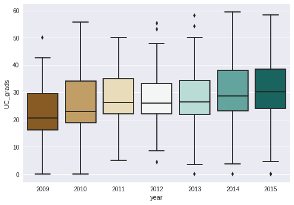

```python
sns.boxplot(x="year", y="UC_grads", palette = 'BrBG', data=question1)
```

#### How does gender determine the prospect of graduating with the necessary academic qualification to attend a university?

Just like in question 1, we will be using a violin plot.

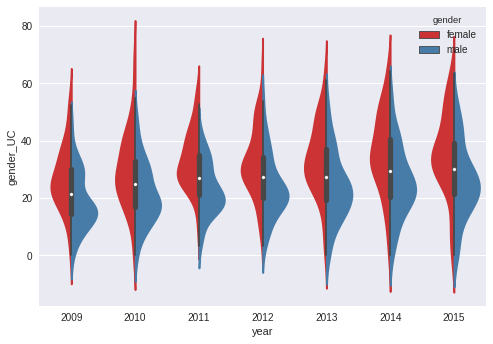

```python
sns.violinplot(x='year', y='gender_UC', palette = 'Set1', hue="gender",  data=gender_UC_q3, split=True)
```

The violin plot shows that female students have a higher percentage of graduating with the necessary UC qualifications.  
Let's look at a swamplot to see if we can see more data.

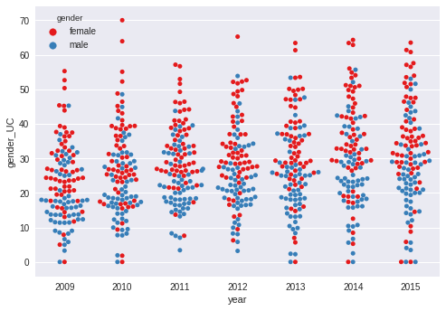

```python
sns.swarmplot(x='year', y='gender_UC', palette = 'Set1', hue="gender",  data=gender_UC_q3)
```

The swamplot shows the same results. It appears that the percentage female students qualified to attend college is increasing at a higher rate than the one for male students.

## Hypothesis Testing and Training Data

In the following section, we will conduct hypothesis testing and use machine learning algorithms to gain some intuition and check if our initial assumptions have been met.

For question 1, we have seen that male, minority, and grade 12 students are most likely to drop out from school. Also for question 3, our assumption is that female students are more likely to have the UC requirements when they graduate. We also want to make future predictions of dropout and qualified percentages. In order to do them, we are going to use machine learning to gain necessary insights.

For our machine learning algorithm, we will be using a random forest. We will use randomforestregressor from scikit learn. According to scikit learn, "A random forest is a meta estimator that fits a number of classifying decision trees on various sub-samples of the dataset and use averaging to improve the predictive accuracy and control over-fitting." For more information, visit [here](http://scikit-learn.org/stable/modules/generated/sklearn.ensemble.RandomForestRegressor.html) [3].

We will the proceeding in this manner:

```python
question1.head(5)
```

|  | COUNTY | year | Drop_percentage | Drop_percentage_M | Drop_percentage_F | Drop_percentage_min | Drop_percentage_maj | Drop_percentage_9 | Drop_percentage_10 | Drop_percentage_11 | Drop_percentage_12 | UC_grads | F_UC_grads | M_UC_grads |
| --- | --- | --- | --- | --- | --- | --- | --- | --- | --- | --- | --- | --- | --- | --- |
| 0 | Alameda | 2009 | 25.955449 | 29.281116 | 22.510004 | 25.965124 | 23.750000 | 4.960621 | 5.252434 | 5.340174 | 10.992400 | 34.450753 | 38.939529 | 30.118026 |
| 1 | Alpine | 2009 | 0.000000 | 0.000000 | 0.000000 | 0.000000 | 0.000000 | 0.000000 | 0.000000 | 0.000000 | 0.000000 | 0.000000 | 0.000000 | 0.000000 |
| 2 | Amador | 2009 | 11.671088 | 11.170213 | 12.169312 | 10.833333 | 29.411765 | 0.840336 | 1.357466 | 1.555556 | 6.511628 | 23.607427 | 29.629630 | 17.553191 |
| 3 | Butte | 2009 | 18.828452 | 21.819527 | 15.661707 | 18.332052 | 66.666667 | 1.599064 | 1.846966 | 4.183195 | 10.066179 | 18.372005 | 21.221613 | 15.680473 |
| 4 | Calaveras | 2009 | 9.459459 | 10.763889 | 8.223684 | 9.369676 | 20.000000 | 0.853242 | 1.654412 | 1.970443 | 5.244755 | 12.500000 | 15.789474 | 9.027778 |

In order to predict dropout percentages, we have to chose male, minority, and grade 12 students as predictors. They are chosen based on the analysis and visualization that were done in the previous section.

```python
#For Q1
x_train = question1.as_matrix(['Drop_percentage_M','Drop_percentage_min','Drop_percentage_12'])
y_train = question1.as_matrix(['Drop_percentage'])
y_train = [val for sublist in y_train for val in sublist]

x_test = question1_2016.as_matrix(['Drop_percentage_M','Drop_percentage_min','Drop_percentage_12'])
y_test = question1_2016.as_matrix(['Drop_percentage'])
y_test = [val for sublist in y_test for val in sublist]


clf = RandomForestRegressor()
clf.fit(x_train,y_train)
```

```
RandomForestRegressor(bootstrap=True, criterion='mse', max_depth=None,
           max_features='auto', max_leaf_nodes=None,
           min_impurity_split=1e-07, min_samples_leaf=1,
           min_samples_split=2, min_weight_fraction_leaf=0.0,
           n_estimators=10, n_jobs=1, oob_score=False, random_state=None,
           verbose=0, warm_start=False)
```

For predicting qualified percentages, we are only using female students as predictors. This was also chosen based on the analysis and visualization that were done in the previous section. As stated at the beginning, we are using datasets from year 2009 to 2015 for training. We will then test them on the 2016 year data to analyze our predictions.

```python
#For Q3
x_train1 = question1.as_matrix(['F_UC_grads'])
y_train1 = question1.as_matrix(['UC_grads'])
y_train1 = [val for sublist in y_train1 for val in sublist]

x_test1 = question1_2016.as_matrix(['F_UC_grads'])
y_test1 = question1_2016.as_matrix(['UC_grads'])
y_test1 = [val for sublist in y_test1 for val in sublist]


clf1 = RandomForestRegressor()
clf1.fit(x_train1,y_train1)
```

```
RandomForestRegressor(bootstrap=True, criterion='mse', max_depth=None,
           max_features='auto', max_leaf_nodes=None,
           min_impurity_split=1e-07, min_samples_leaf=1,
           min_samples_split=2, min_weight_fraction_leaf=0.0,
           n_estimators=10, n_jobs=1, oob_score=False, random_state=None,
           verbose=0, warm_start=False)
```

## Data Testing

We will use cross validation with 10 K-Fold splits to test our predictions. Accuracy rates for both predictions are stated below. Predicted vs Actual values plot has been produced as well.

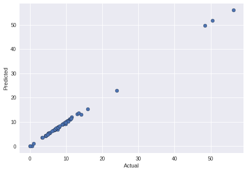

```
[ 0.98861402  0.93693792  0.99916619  0.99813585  0.99725216  0.99564147
  0.99951232  0.99910577  0.98900875  0.99899133]
Accuracy RandomForest on train: 0.99 (+/- 0.04)
Error rate Random Forest on train: 0.01
Accuracy score on Test: 0.998553255894
[ 0.9758449   0.60038738  0.94369085  0.98548756  0.9595392   0.99153835
  0.99383964  0.99245739  0.99430919  0.96462998]
Accuracy RandomForest on test: 0.94 (+/- 0.23)
Error rate Random Forest on test: 0.04
```

```python
#For Q1

import matplotlib.pyplot as plt

predicted = clf.predict(x_test)

fig, ax = plt.subplots()
ax.scatter(y_test, predicted, edgecolors=(0, 0, 0))
ax.set_xlabel('Actual')
ax.set_ylabel('Predicted')
plt.show()

kfold = KFold(n_splits=10)
scores1 = cross_val_score(clf, x_train, y_train, cv=kfold)
print (scores1)
print("Accuracy RandomForest on train: %0.2f (+/- %0.2f)" % (scores1.mean(), scores1.std() * 2))
print("Error rate Random Forest on train: %0.2f" % (stats.sem(scores1)))
#clfPredict = clf.predict(x_test)
#print("Accuracy score Pred: " + str(accuracy_score(y_test, clfPredict)))
print("Accuracy score on Test: " + str(clf.score(x_test,y_test)))
scores1 = cross_val_score(clf, x_test, y_test, cv=kfold)
print (scores1)
print("Accuracy RandomForest on test: %0.2f (+/- %0.2f)" % (scores1.mean(), scores1.std() * 2))
print("Error rate Random Forest on test: %0.2f" % (stats.sem(scores1)))
```

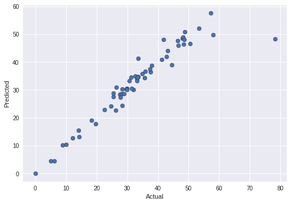

```
[ 0.97292706  0.95537277  0.9449357   0.90036525  0.96204979  0.90790353
  0.98495567  0.96707114  0.96393624  0.97836267]
Accuracy RandomForest on train: 0.95 (+/- 0.05)
Error rate Random Forest on train: 0.01
Accuracy score on Test: 0.895904142681
[ 0.96038062  0.97841467  0.97990101  0.93015488  0.97285463  0.97834093
  0.9593041   0.72643272  0.71685347  0.91967696]
Accuracy RandomForest on test: 0.91 (+/- 0.19)
Error rate Random Forest on test: 0.03
```

```python
#For Q3

predicted = clf1.predict(x_test1)

fig, ax = plt.subplots()
ax.scatter(y_test1, predicted, edgecolors=(0, 0, 0))
ax.set_xlabel('Actual')
ax.set_ylabel('Predicted')
plt.show()

kfold2 = KFold(n_splits=10)
scores2 = cross_val_score(clf1, x_train1, y_train1, cv=kfold2)
print (scores2)
print("Accuracy RandomForest on train: %0.2f (+/- %0.2f)" % (scores2.mean(), scores2.std() * 2))
print("Error rate Random Forest on train: %0.2f" % (stats.sem(scores2)))
#clfPredict = clf.predict(x_test)
#print("Accuracy score Pred: " + str(accuracy_score(y_test, clfPredict)))
print("Accuracy score on Test: " + str(clf1.score(x_test1,y_test1)))
scores2 = cross_val_score(clf1, x_test1, y_test1, cv=kfold2)
print (scores2)
print("Accuracy RandomForest on test: %0.2f (+/- %0.2f)" % (scores2.mean(), scores2.std() * 2))
print("Error rate Random Forest on test: %0.2f" % (stats.sem(scores2)))
```

## Analysis of Results and Conclusion

From the above scores, we can see that both models did pretty well. We can see from the plots that there is a linear relationship in between predicted and the actual values. This means that there is a relationhip present in between the predictors and the outcome.

We can now say that our initial assumptions are true since the models are pretty accurate.

For a follow-up analysis, one can replicate the same steps that have been done here, but one can go over one particular county and group the data by district or school. This could give a further understanding of what occurs in low-performance counties like Inyo, Nevada, and Mono.

## References

[1] "Population by Race and Hispanic or Latino Origin, for All Ages and for 18 Years and Over, for California: 2000" PDF. Census.gov. Retrieved 11 December 2017.  
[2] Michael, J., County table. [Page](https://en.wikipedia.org/wiki/User:Michael_J/County_table). Retrieved 12 December 2017, from https://en.wikipedia.org/wiki/User:Michael_J/County_table  
[3] 3.2.4.3.2. sklearn.ensemble.RandomForestRegressor¶. (n.d.). Retrieved December 15, 2017, from http://scikit-learn.org/stable/modules/generated/sklearn.ensemble.RandomForestRegressor.html